# Machine Learning Peer Assignment

## Summary

The purpose of this assignment is to predict how well 6 experimental participants are using a dumbbell, using data from accelerometers on the belt, forearm, arm, and dumbbell of the participants.

To do this I trained a model using a random forest algorithm, with 10-fold cross-validation, and a training dataset consisting of 75% of the data. Accuracy on the test dataset was greater than 99%.

## 1. Set up

```r
library(caret)
library(Amelia)
```

## 2. Data preparation

#### 2.1 Download data

First I downloaded the data, setting blanks to NA.

```r
pml_training <- read.csv("https://d396qusza40orc.cloudfront.net/predmachlearn/pml-training.csv", na.strings=c("", "NA"))
pml_testing <- read.csv("https://d396qusza40orc.cloudfront.net/predmachlearn/pml-testing.csv", na.strings=c("", "NA"))
```

An examination of the data shows there are 19622 observations of 160 variables.

```r
dim(pml_training)
```

```
## [1] 19622   160
```

```r
head(pml_training)[1:10]
```

```
##   X user_name raw_timestamp_part_1 raw_timestamp_part_2   cvtd_timestamp
## 1 1  carlitos           1323084231               788290 05/12/2011 11:23
## 2 2  carlitos           1323084231               808298 05/12/2011 11:23
## 3 3  carlitos           1323084231               820366 05/12/2011 11:23
## 4 4  carlitos           1323084232               120339 05/12/2011 11:23
## 5 5  carlitos           1323084232               196328 05/12/2011 11:23
## 6 6  carlitos           1323084232               304277 05/12/2011 11:23
##   new_window num_window roll_belt pitch_belt yaw_belt
## 1         no         11      1.41       8.07    -94.4
## 2         no         11      1.41       8.07    -94.4
## 3         no         11      1.42       8.07    -94.4
## 4         no         12      1.48       8.05    -94.4
## 5         no         12      1.48       8.07    -94.4
## 6         no         12      1.45       8.06    -94.4
```

The first seven columns relate to features such as row numbers, time stamps and other information not relevant for the prediction, so I removed them.

```r
pml_training <- pml_training[,c(8:160)]
```

#### 2.2 Examine missing data

Many of the variables appear to have missing data. A missing map allows us to easily view the distribution of these missing variables.

```r
sum(is.na(pml_training))
```

```
## [1] 1921600
```

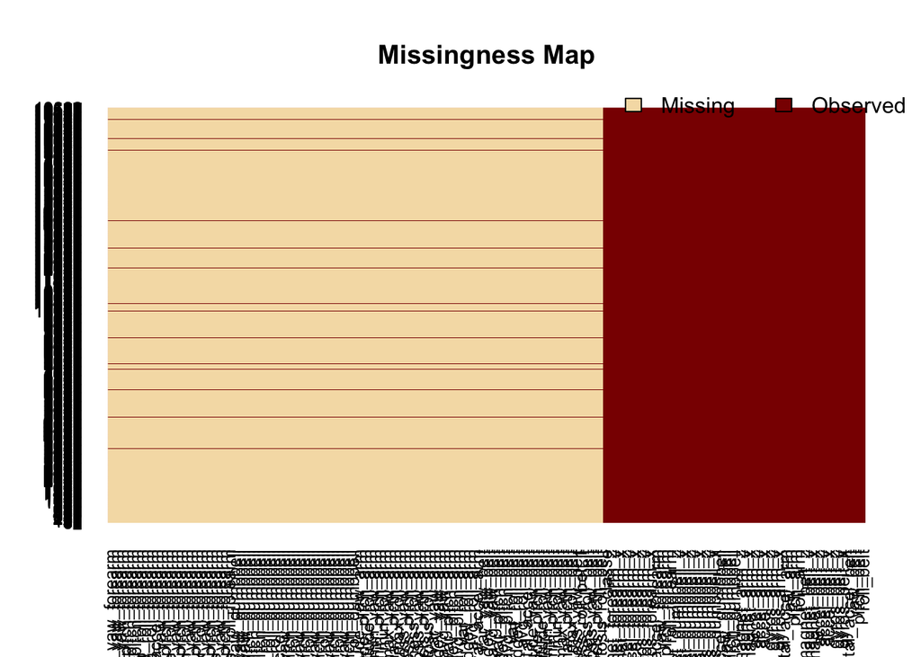

```r
missmap(pml_training)
```

Many columns are missing most variables, whereas all other columns complete. As a result, we will restrict our analysis to those variables that are complete.

```r
missingNone <- apply(pml_training, 2, function(x) sum(is.na(x))==0)
pml_training <- pml_training[,missingNone]
```

This leaves me with 52 predictors.

## 3. Modelling

#### 3.1 Cross validation and testing

I created a test dataset comprising 25% of the data to test the accuracy of the model before submitting the quiz answers.

```r
set.seed(20170909)
inTrain <- createDataPartition(pml_training$classe, p = 0.75, list=FALSE)
training <- pml_training[inTrain,]
testing <- pml_training[-inTrain,]
```

#### 3.2 Model training

I used 10-fold cross validation for development of the random forest model.

```r
ctrl <- trainControl(method = "cv", number = 10)
```

I implemented a random forest model on the training dataset. I selected a random forest model as this is a classification problem, and random forest is typically a robust choice that is quick to train. Although interpretation of random forests can be difficult, this is a prediction task and I am willing to sacrifice interpretability for the other strengths of the random forest.

```r
model1 <- train(classe ~., method = "rf", data=training, trControl=ctrl)
model1
```

```
## Random Forest
##
## 14718 samples
##    52 predictor
##     5 classes: 'A', 'B', 'C', 'D', 'E'
##
## No pre-processing
## Resampling: Cross-Validated (10 fold)
## Summary of sample sizes: 13247, 13247, 13246, 13247, 13247, 13245, ...
## Resampling results across tuning parameters:
##
##   mtry  Accuracy   Kappa
##    2    0.9924575  0.9904583
##   27    0.9928654  0.9909751
##   52    0.9905549  0.9880517
##
## Accuracy was used to select the optimal model using  the largest value.
## The final value used for the model was mtry = 27.
```

The accuracy of the model is very high, with accuracy of 0.9928654 with 27 variables sampled. The confusion matrix of the training dataset also points to this accuracy. The estimate out-of-bag error rate is 0.0059

```r
model1$finalModel
```

```
##
## Call:
##  randomForest(x = x, y = y, mtry = param$mtry)
##                Type of random forest: classification
##                      Number of trees: 500
## No. of variables tried at each split: 27
##
##         OOB estimate of  error rate: 0.59%
## Confusion matrix:
##      A    B    C    D    E class.error
## A 4178    4    1    0    2 0.001672640
## B   14 2826    7    0    1 0.007724719
## C    0   14 2541   12    0 0.010128555
## D    0    0   23 2387    2 0.010364842
## E    0    0    3    4 2699 0.002586844
```

#### 3.3 Model error plot

The error is minimised at around 100 trees.

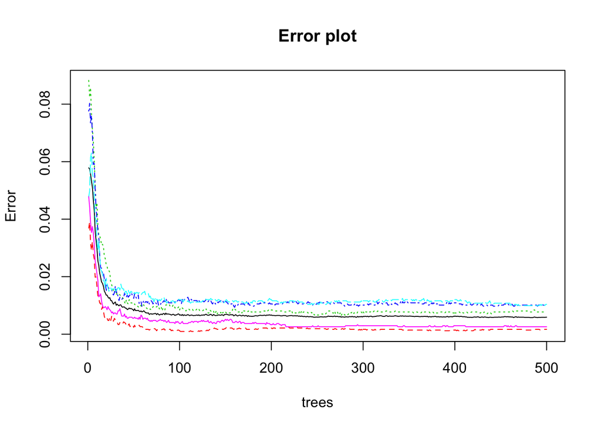

```r
plot(model1$finalModel, main="Error plot")
```

#### 3.4 Model testing

We can see this through the classification accuracy on the test data set.

```r
testPredict <- predict(model1, testing)
confusionMatrix(testPredict, testing$classe)
```

```
## Confusion Matrix and Statistics
##
##           Reference
## Prediction    A    B    C    D    E
##          A 1393   10    0    0    0
##          B    2  936    7    0    1
##          C    0    3  844   10    1
##          D    0    0    4  792    1
##          E    0    0    0    2  898
##
## Overall Statistics
##
##                Accuracy : 0.9916
##                  95% CI : (0.9887, 0.994)
##     No Information Rate : 0.2845
##     P-Value [Acc > NIR] : < 2.2e-16
##
##                   Kappa : 0.9894
##  Mcnemar's Test P-Value : NA
##
## Statistics by Class:
##
##                      Class: A Class: B Class: C Class: D Class: E
## Sensitivity            0.9986   0.9863   0.9871   0.9851   0.9967
## Specificity            0.9972   0.9975   0.9965   0.9988   0.9995
## Pos Pred Value         0.9929   0.9894   0.9837   0.9937   0.9978
## Neg Pred Value         0.9994   0.9967   0.9973   0.9971   0.9993
## Prevalence             0.2845   0.1935   0.1743   0.1639   0.1837
## Detection Rate         0.2841   0.1909   0.1721   0.1615   0.1831
## Detection Prevalence   0.2861   0.1929   0.1750   0.1625   0.1835
## Balanced Accuracy      0.9979   0.9919   0.9918   0.9919   0.9981
```

The accuracy on the cross-validation dataset is 0.9916395

Given this, I am confident with the quiz predictions. Predictions for the quiz are as follows.

```r
quizPredict <- predict(model1, pml_testing)
quizPredict
```

```
##  [1] B A B A A E D B A A B C B A E E A B B B
## Levels: A B C D E
```

## 4. References

Velloso, E.; Bulling, A.; Gellersen, H.; Ugulino, W.; Fuks, H. [Qualitative Activity Recognition of Weight Lifting Exercises](http://web.archive.org/web/20161224072740/http:/groupware.les.inf.puc-rio.br/work.jsf?p1=11201). Proceedings of 4th International Conference in Cooperation with SIGCHI (Augmented Human ’13) . Stuttgart, Germany: ACM SIGCHI, 2013.